# EEfRT_forPACO

this document is a record of the analysis of EEfRT for PACO

## Effrt: LOSS

constants used in analysis

```r
N_SKIP_CHOICE = 4 # 4 is more than 10% of trials not making a choice
N_INCOMPLETE = 4
```

There are a few subjects for whom we don’t (potentially?) have data. > 2747, no loss file found 2687 < 10 trials in file.

```
## setwd("/Users/Jim/Dropbox/EEFRT_analysis/") ~ library(reshape2)
```

load data, make data frame.

```r
## data file was created with '~Dropbox/PACO_JS/EEfRT_analysis/code/aggregate matlab EEfrt Loss.R'
lossEffrt_raw <- read.csv("~/Dropbox/PACO_JS/EEfRT_analysis/EEfRTloss_agg_network_nov_2014.csv")
lossEffrt_raw$subID<-factor(lossEffrt_raw$subID)
subs <- read.csv("~/Dropbox/PACO_JS/subsGroups.csv")
subs$Subject<-factor(subs$Subject)
lossEffrt<-merge(lossEffrt_raw,subs,all.x=T,all.y=F,by.x="subID",by.y="Subject",sort=F)


### missing data!
setdiff(subs$Subject,lossEffrt_raw$subID)
```

```
## [1] "2507" "2747"
```

```r
##3 missing subject!
setdiff(lossEffrt_raw$subID,subs$Subject)
```

```
## character(0)
```

some data cleaning.

```r
#how many trials not chosen
xtabs(~choice+Group,lossEffrt) ##pretty neglibible, skip it for now
```

```
##            Group
## choice      COMO CTL GAD MDD
##   l          307 270 227 246
##   No Answer   40  26  30  28
##   s          317 301 266 252
```

```r
# how many trials not completed
xtabs(~completeTrue+Group,lossEffrt) ##pretty neglibible, skip it for now
```

```
##             Group
## completeTrue COMO CTL GAD MDD
##            0   10   5  14  12
##            1  654 592 509 514
```

```r
### find bad 'subjects', choices
choicesmade <- dcast(lossEffrt,subID+Group~choice,
      fun.aggregate = length,value.var = "choice",drop = FALSE)
names(choicesmade) <- fixDCastNames(choicesmade)
badsubs_fewchoice <- choicesmade[choicesmade$NoAnswer > N_SKIP_CHOICE,'subID',]
# these subjects missed many choices
choicesmade[choicesmade$subID==badsubs_fewchoice & choicesmade$s!=0,] #slight hack, if no times chose s, will not be displayed
```

```
##     subID Group  l NoAnswer  s
## 1    2622  COMO 15       11  7
## 247  2835   GAD  1        5 20
## 272  2853   MDD 22        5  9
```

```r
### find bad 'subjects', completed trials
completedtrials <- dcast(lossEffrt,subID+Group~completeTrue,
      fun.aggregate = length,value.var = "choice",drop = FALSE)
names(completedtrials) <- fixDCastNames(completedtrials)
badsubs_incomplete <- completedtrials[completedtrials$no > N_INCOMPLETE,'subID']
#these subjects didnt finish many trials
completedtrials[completedtrials$subID==badsubs_incomplete & completedtrials$yes!=0 ,]
```

```
## [1] subID Group no    yes
## <0 rows> (or 0-length row.names)
```

> drop trials not completed, and not chosen, drop bad subs (based on cutoffs)

```r
missingDataSubs <- c(2687,2747)

lossEffrt<-lossEffrt[is.finite(lossEffrt$choice),]
lossEffrt<- lossEffrt[lossEffrt$choice !="No Answer",]
lossEffrt <- lossEffrt[!lossEffrt$subID %in% c(missingDataSubs,badsubs_incomplete,badsubs_fewchoice),]
lossEffrt <- lossEffrt[lossEffrt$completeTrue==1,]
lossEffrt$choosehard<-lossEffrt$difficulty=='h'
```

### Group dif in choosing hard task?

ratio: total numberhard tasks chosen/number of trials (choices made). Ratios are computed for each subjcet

```
##   Group EEfRT_ratio
## 1  COMO      0.5994
## 2   CTL      0.6362
## 3   GAD      0.5602
## 4   MDD      0.5574
```

```
## group: COMO
##   vars  n mean   sd median trimmed  mad  min max range skew kurtosis   se
## 1    1 20  0.6 0.25   0.64    0.59 0.36 0.25   1  0.75 0.18    -1.37 0.06
## --------------------------------------------------------
## group: CTL
##   vars  n mean   sd median trimmed  mad  min max range skew kurtosis   se
## 1    1 18 0.64 0.25   0.58    0.64 0.33 0.28   1  0.72 0.14    -1.62 0.06
## --------------------------------------------------------
## group: GAD
##   vars  n mean   sd median trimmed  mad  min  max range skew kurtosis   se
## 1    1 16 0.56 0.21   0.55    0.56 0.13 0.13 0.95  0.82 0.16    -0.31 0.05
## --------------------------------------------------------
## group: MDD
##   vars  n mean   sd median trimmed  mad min max range skew kurtosis   se
## 1    1 16 0.56 0.26   0.52    0.55 0.29 0.2   1   0.8 0.39    -1.19 0.06
```

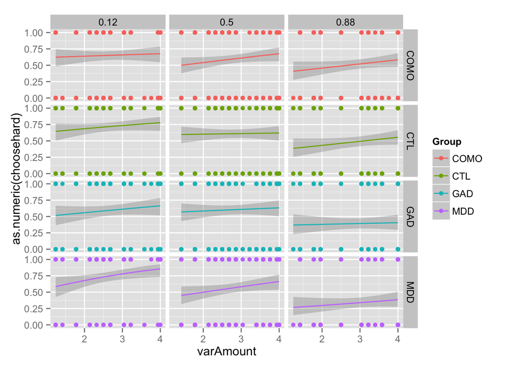

```r
ggplot(lossEffrt,aes(x=varAmount,y=as.numeric(choosehard),color=Group))+stat_smooth(method=glm,family='binomial') + geom_point()+facet_grid(Group~prob)
```

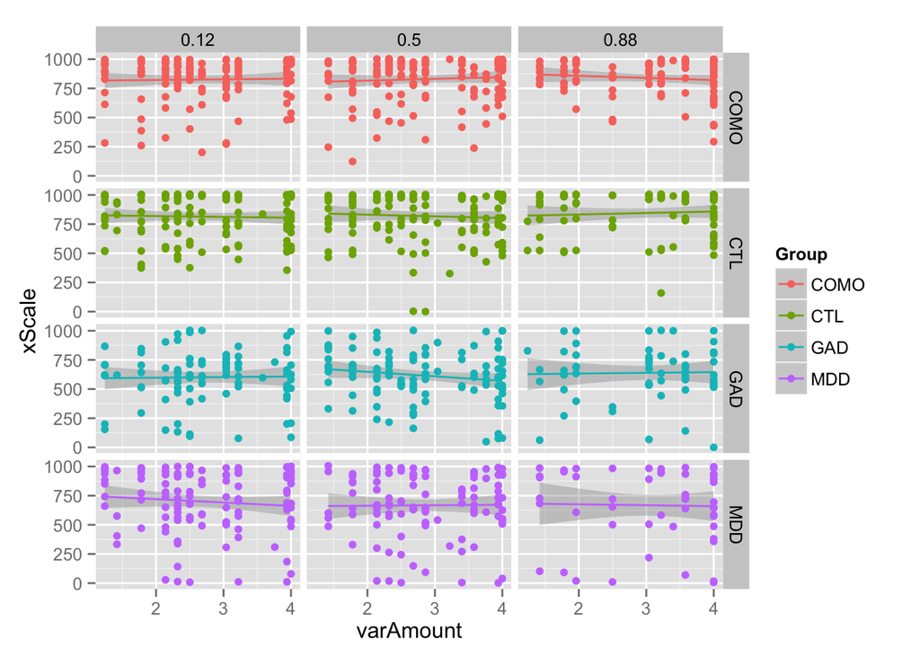

```r
# subjctive effort, choose hard task first
ggplot(lossEffrt[lossEffrt$choosehard==TRUE,],aes(x=varAmount,y=xScale,color=Group))+geom_smooth(method='lm') + geom_point()+facet_grid(Group~prob)
```

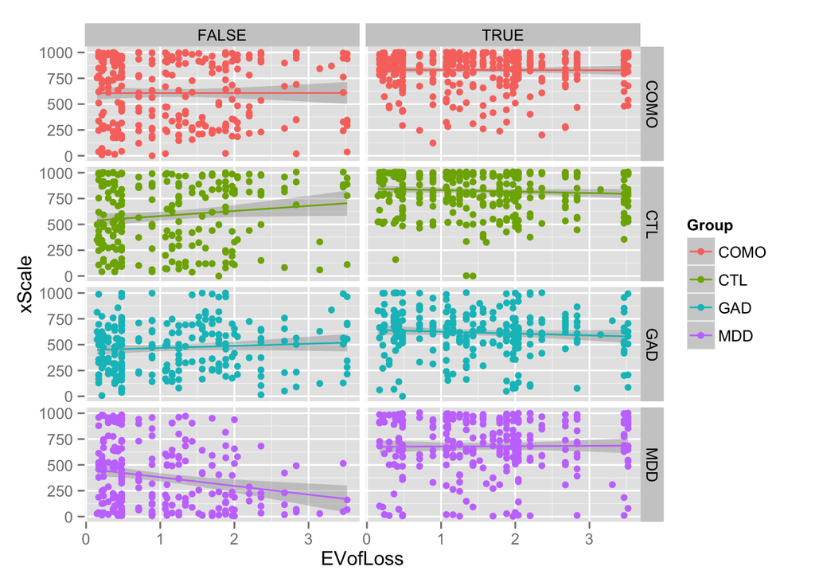

```r
### using expected value loss, compare 2 tasks
lossEffrt$EVofLoss <- lossEffrt$varAmount * (1-lossEffrt$prob)
ggplot(lossEffrt,aes(x=EVofLoss,y=xScale,color=Group))+geom_smooth(method='lm') + geom_point()+facet_grid(Group~choosehard)
```

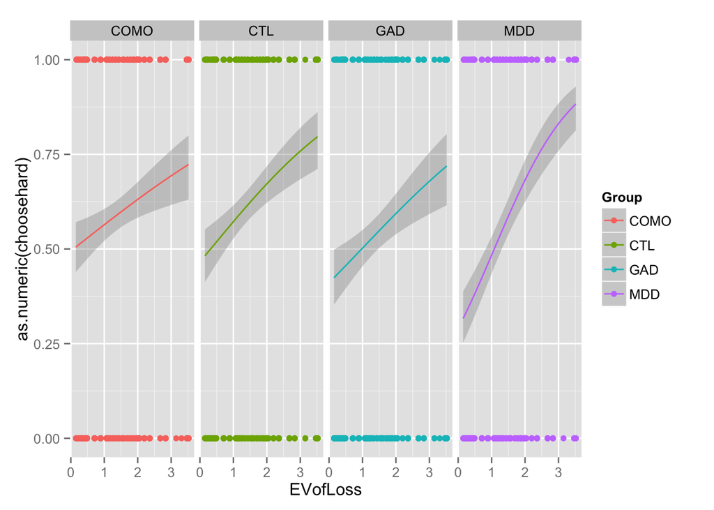

```r
# choice by ev of loss
ggplot(lossEffrt,aes(x=EVofLoss,y=as.numeric(choosehard),color=Group))+stat_smooth(method=glm,family='binomial') + geom_point()+facet_grid(~Group)
```

```r
suppressPackageStartupMessages(library('lme4'))
# suppressPackageStartupMessages(library(lmerTest))
suppressPackageStartupMessages(library('effects'))
con<-cbind(CtlvsAll=c(-1,3,-1,-1),GADPUREvMDD=c(-1,0,2,-1),MDDpurevCOmo=c(-1,0,0,1)) # create matrix of desired contrasts, give sensible names to each
lossEffrt$GroupC2<-C(lossEffrt$Group,con)  #create new factor variable w/ new contrasts
contrasts(lossEffrt$GroupC2)
```

```
##      CtlvsAll GADPUREvMDD MDDpurevCOmo
## COMO       -1          -1           -1
## CTL         3           0            0
## GAD        -1           2            0
## MDD        -1          -1            1
```

```r
r1 <- glmer(choosehard~GroupC2*EVofLoss + (1|subID),lossEffrt, family='binomial')
r1slope <- glmer(choosehard~GroupC2*EVofLoss + (1+EVofLoss| subID),lossEffrt, family='binomial')
# r1slope <- glmer(choosehard~GroupC2*EVofLoss + (1+EVofLoss| subID),lossEffrt[lossEffrt$gotnewinstructions==TRUE,], family='binomial')
summary(r1)
```

```
## Generalized linear mixed model fit by maximum likelihood (Laplace
##   Approximation) [glmerMod]
##  Family: binomial  ( logit )
## Formula: choosehard ~ GroupC2 * EVofLoss + (1 | subID)
##    Data: lossEffrt
##
##      AIC      BIC   logLik deviance df.resid
##     2496     2547    -1239     2478     2151
##
## Scaled residuals:
##    Min     1Q Median     3Q    Max
## -4.970 -0.758  0.249  0.715  3.248
##
## Random effects:
##  Groups Name        Variance Std.Dev.
##  subID  (Intercept) 1.84     1.36
## Number of obs: 2160, groups:  subID, 70
##
## Fixed effects:
##                              Estimate Std. Error z value Pr(>|z|)
## (Intercept)                   -0.2547     0.1888   -1.35    0.177
## GroupC2CtlvsAll                0.1396     0.1075    1.30    0.194
## GroupC2GADPUREvMDD             0.0543     0.1561    0.35    0.728
## GroupC2MDDpurevCOmo           -0.6064     0.2660   -2.28    0.023 *
## EVofLoss                       0.6005     0.0592   10.15  < 2e-16 ***
## GroupC2CtlvsAll:EVofLoss      -0.0316     0.0329   -0.96    0.336
## GroupC2GADPUREvMDD:EVofLoss   -0.0981     0.0472   -2.08    0.038 *
## GroupC2MDDpurevCOmo:EVofLoss   0.3859     0.0877    4.40  1.1e-05 ***
## ---
## Signif. codes:  0 '***' 0.001 '**' 0.01 '*' 0.05 '.' 0.1 ' ' 1
##
## Correlation of Fixed Effects:
##                (Intr) GrC2CA GrC2GADPUREMDD GrC2MDDCO EVfLss GC2CA:
## GrpC2CtlvsA    -0.019
## GrC2GADPUREMDD  0.019 -0.012
## GrpC2MDDpCO     0.097 -0.059 -0.079
## EVofLoss       -0.395  0.028  0.027         -0.092
## GrpC2CA:EVL     0.024 -0.394 -0.016          0.054    -0.062
## GC2GADPUREMDD:  0.026 -0.018 -0.396          0.076    -0.093  0.054
## GC2MDDCO:EV    -0.081  0.052  0.068         -0.421     0.234 -0.138
##                GC2GADPUREMDD:
## GrpC2CtlvsA
## GrC2GADPUREMDD
## GrpC2MDDpCO
## EVofLoss
## GrpC2CA:EVL
## GC2GADPUREMDD:
## GC2MDDCO:EV    -0.193
```

```r
summary(r1slope)
```

```
## Generalized linear mixed model fit by maximum likelihood (Laplace
##   Approximation) [glmerMod]
##  Family: binomial  ( logit )
## Formula: choosehard ~ GroupC2 * EVofLoss + (1 + EVofLoss | subID)
##    Data: lossEffrt
##
##      AIC      BIC   logLik deviance df.resid
##     2378     2440    -1178     2356     2149
##
## Scaled residuals:
##    Min     1Q Median     3Q    Max
## -4.464 -0.697  0.188  0.646  3.744
##
## Random effects:
##  Groups Name        Variance Std.Dev. Corr
##  subID  (Intercept) 3.68     1.92
##         EVofLoss    1.17     1.08     -0.63
## Number of obs: 2160, groups:  subID, 70
##
## Fixed effects:
##                              Estimate Std. Error z value Pr(>|z|)
## (Intercept)                   -0.4183     0.2561   -1.63    0.102
## GroupC2CtlvsAll                0.1846     0.1463    1.26    0.207
## GroupC2GADPUREvMDD             0.0665     0.2101    0.32    0.752
## GroupC2MDDpurevCOmo           -0.6094     0.3566   -1.71    0.087 .
## EVofLoss                       0.8219     0.1540    5.34  9.4e-08 ***
## GroupC2CtlvsAll:EVofLoss      -0.0674     0.0848   -0.79    0.427
## GroupC2GADPUREvMDD:EVofLoss   -0.1200     0.1232   -0.97    0.330
## GroupC2MDDpurevCOmo:EVofLoss   0.3558     0.2118    1.68    0.093 .
## ---
## Signif. codes:  0 '***' 0.001 '**' 0.01 '*' 0.05 '.' 0.1 ' ' 1
##
## Correlation of Fixed Effects:
##                (Intr) GrC2CA GrC2GADPUREMDD GrC2MDDCO EVfLss GC2CA:
## GrpC2CtlvsA    -0.006
## GrC2GADPUREMDD  0.021 -0.015
## GrpC2MDDpCO     0.085 -0.052 -0.070
## EVofLoss       -0.664  0.011 -0.002         -0.059
## GrpC2CA:EVL     0.011 -0.666  0.004          0.037    -0.034
## GC2GADPUREMDD: -0.002  0.004 -0.659          0.050    -0.004 -0.003
## GC2MDDCO:EV    -0.058  0.036  0.049         -0.666     0.082 -0.052
##                GC2GADPUREMDD:
## GrpC2CtlvsA
## GrC2GADPUREMDD
## GrpC2MDDpCO
## EVofLoss
## GrpC2CA:EVL
## GC2GADPUREMDD:
## GC2MDDCO:EV    -0.070
```

```r
anova(r1slope)
```

```
## Analysis of Variance Table
##                  Df Sum Sq Mean Sq F value
## GroupC2           3   1.83    0.61    0.61
## EVofLoss          1  28.39   28.39   28.39
## GroupC2:EVofLoss  3   3.98    1.33    1.33
```

```r
anova(r1,r1slope)
```

```
## Data: lossEffrt
## Models:
## r1: choosehard ~ GroupC2 * EVofLoss + (1 | subID)
## r1slope: choosehard ~ GroupC2 * EVofLoss + (1 + EVofLoss | subID)
##         Df  AIC  BIC logLik deviance Chisq Chi Df Pr(>Chisq)
## r1       9 2496 2547  -1239     2478
## r1slope 11 2378 2440  -1178     2356   122      2     <2e-16 ***
## ---
## Signif. codes:  0 '***' 0.001 '**' 0.01 '*' 0.05 '.' 0.1 ' ' 1
```

```r
allEffects(r1)
```

```
##  model: choosehard ~ GroupC2 * EVofLoss
##
##  GroupC2*EVofLoss effect
##        EVofLoss
## GroupC2    0.5      1    1.5      2    2.5      3    3.5
##    COMO 0.5817 0.6229 0.6624 0.6998 0.7347 0.7669 0.7962
##    CTL  0.6028 0.6615 0.7156 0.7641 0.8066 0.8431 0.8737
##    GAD  0.4831 0.5375 0.5910 0.6424 0.6908 0.7353 0.7755
##    MDD  0.3782 0.5152 0.6500 0.7644 0.8501 0.9083 0.9454
```

> need to go to stats consultant. is random slopes approrpiate for logistic regression? (discussion about gees…)